# Data Cleaning

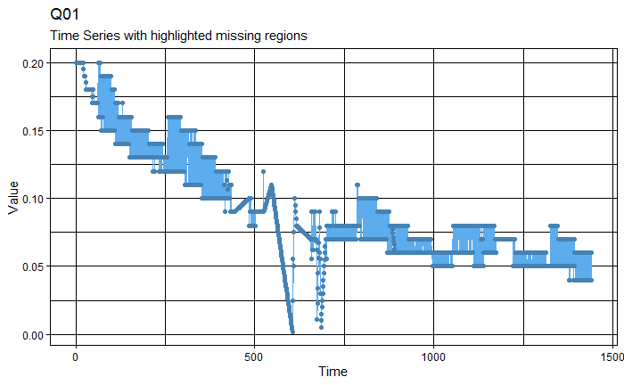

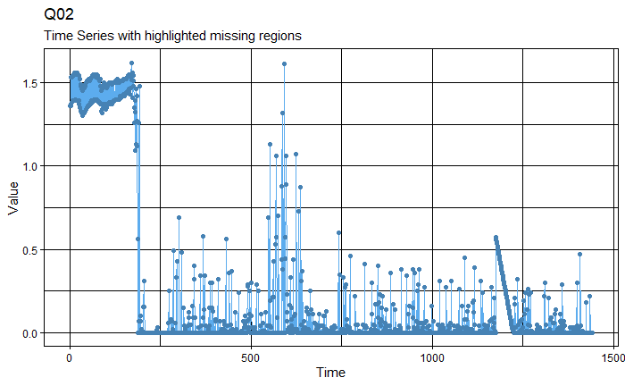

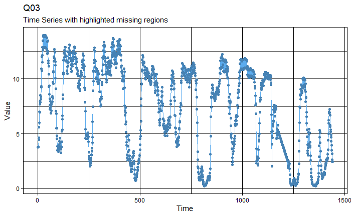

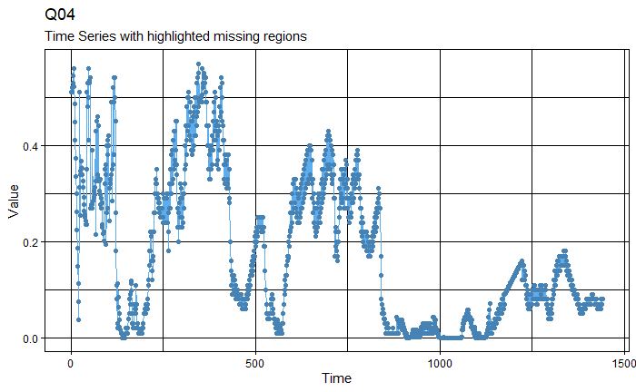

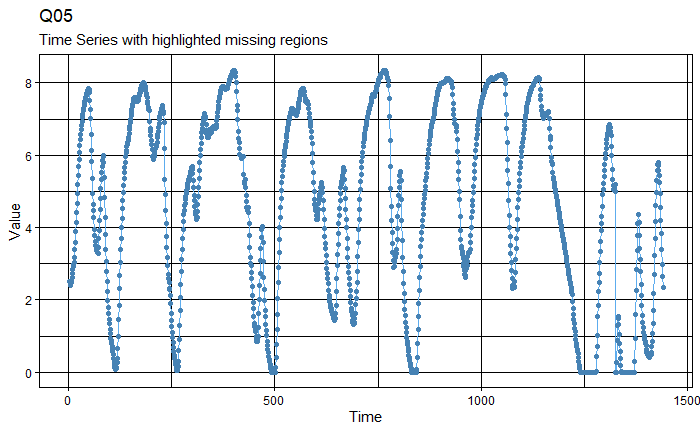

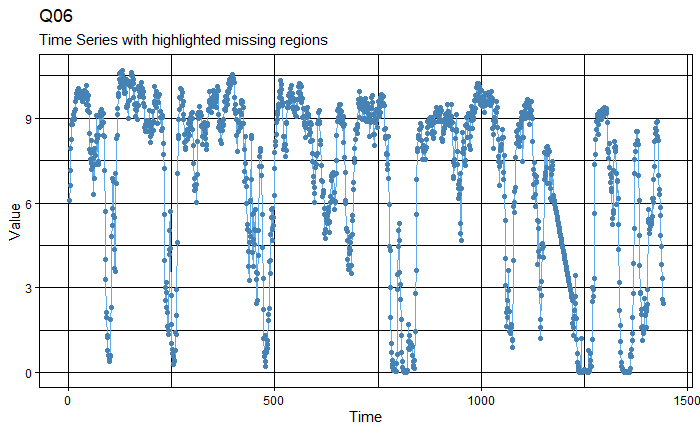

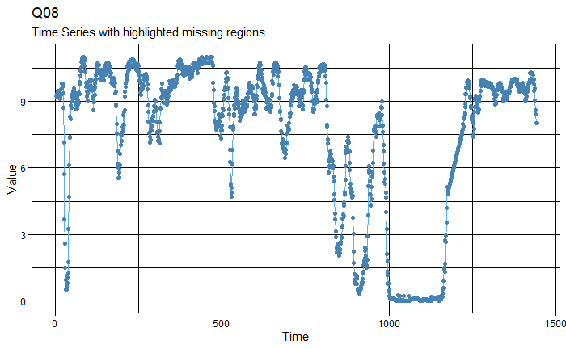

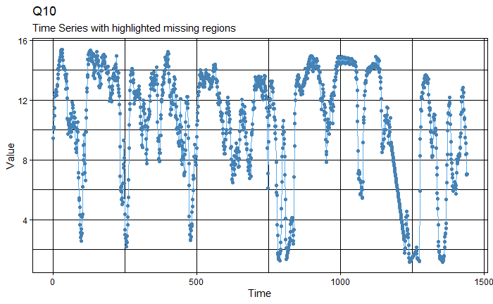

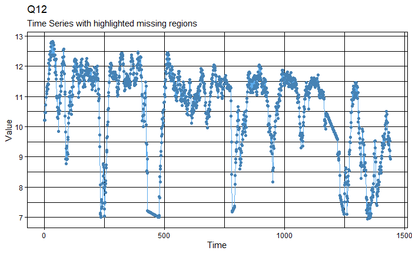

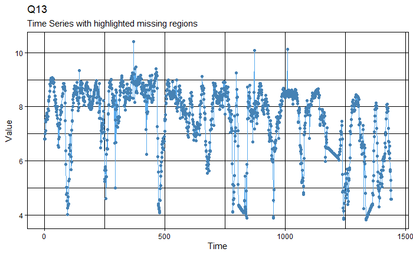

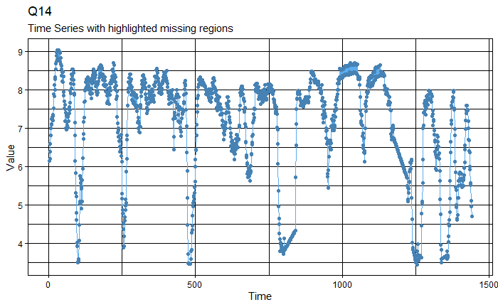

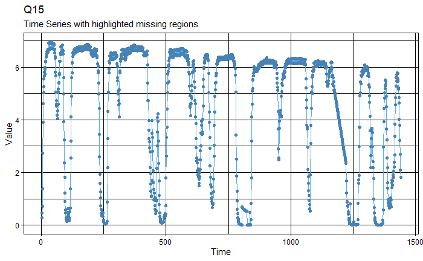

[1 more figures not shown]

```r
df %>% plot_each_q(variable)
```

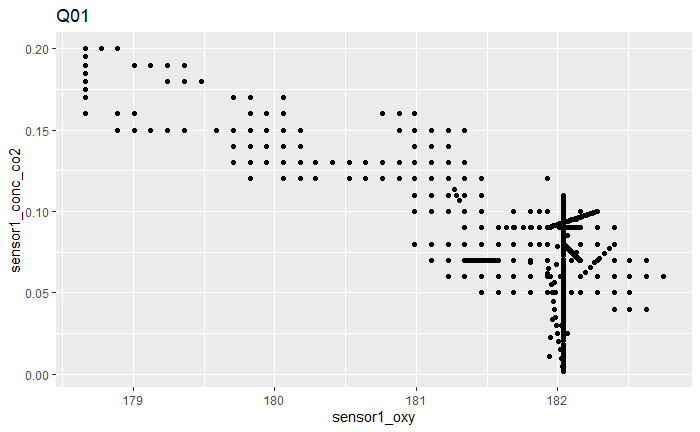

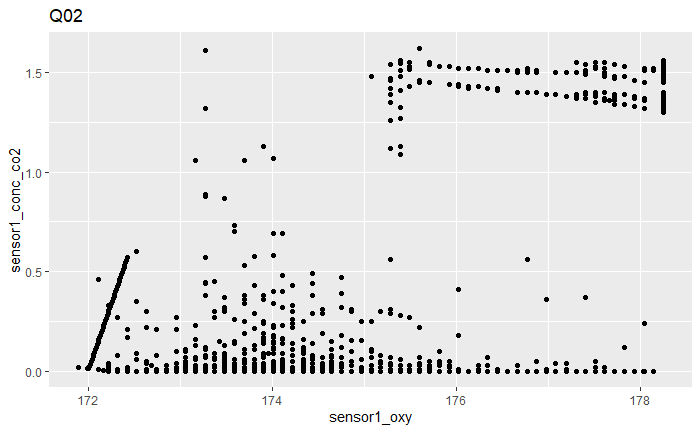

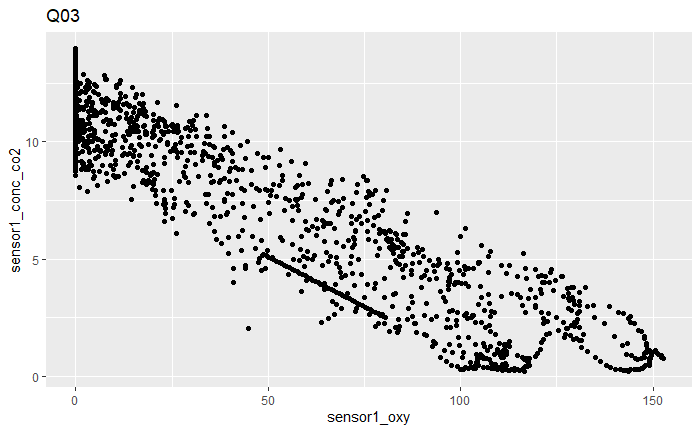

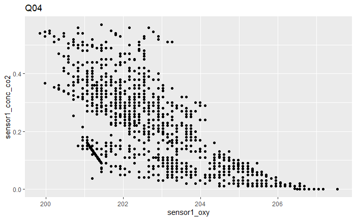

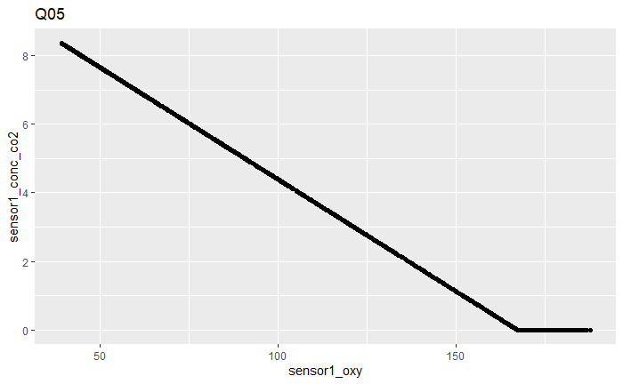

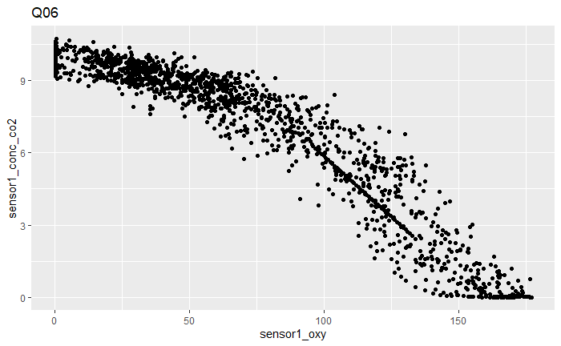

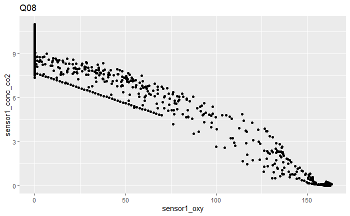

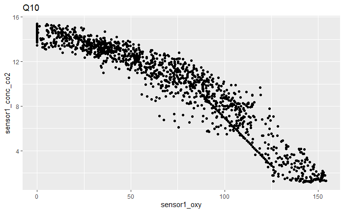

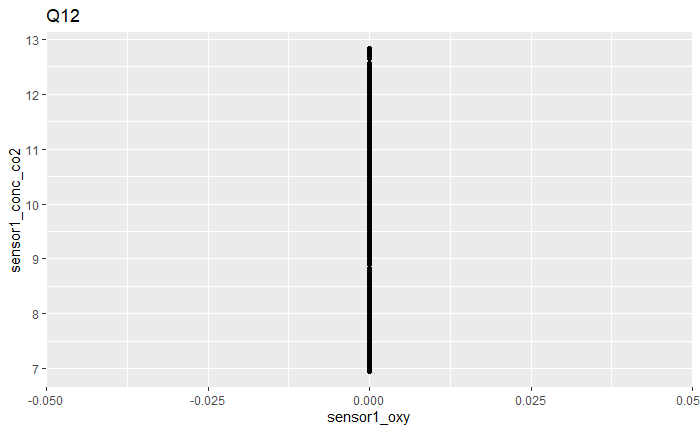

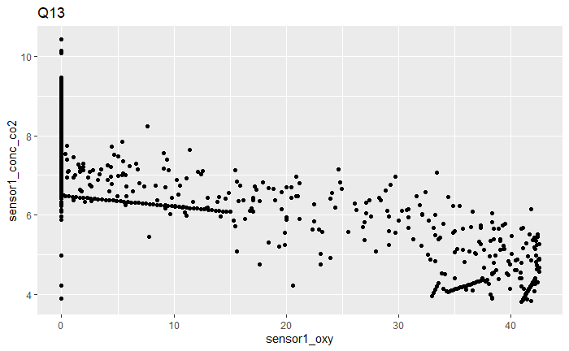

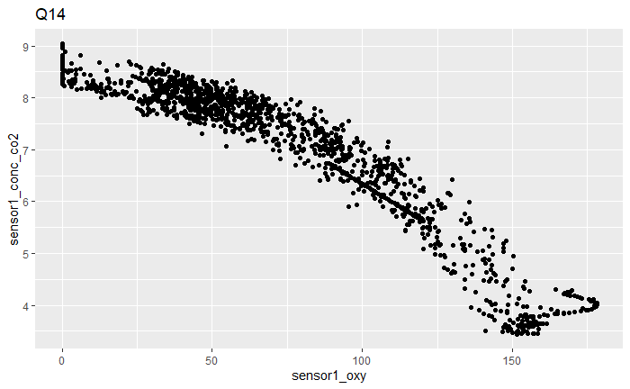

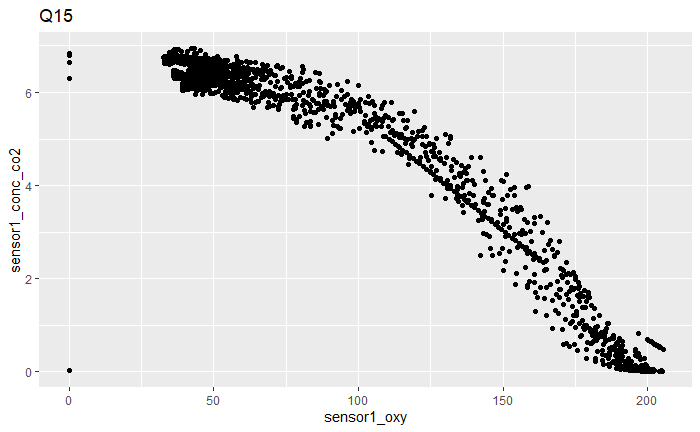

[1 more figures not shown]

```r
df %>% plot_each_q_xy(x="sensor1_oxy", y="sensor1_conc_co2")
```

We turn to sensor3_conc_ch4 for some different examples of cleaning issues.

```r
variable <- "sensor3_conc_ch4"
```

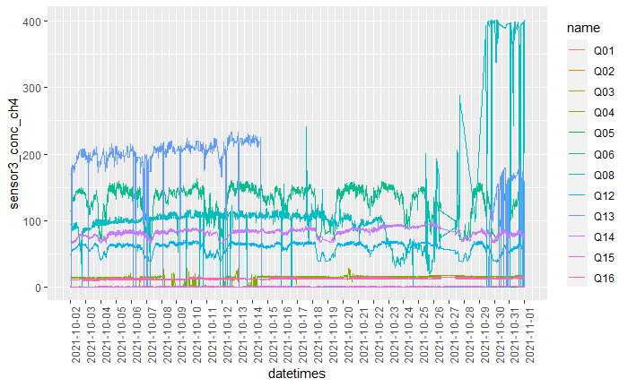

```r
df %>% plot_all_qs_dt(variable, qs_to_ignore=c("Q10")) # Q10 has other issues we can discuss another time...
```

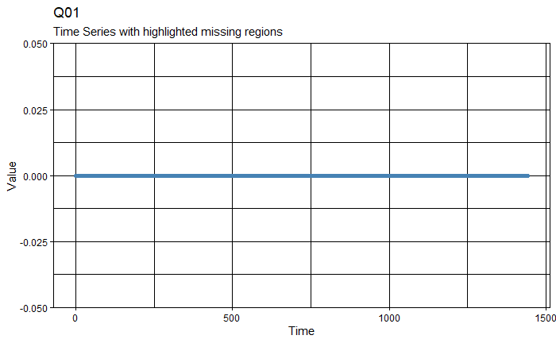

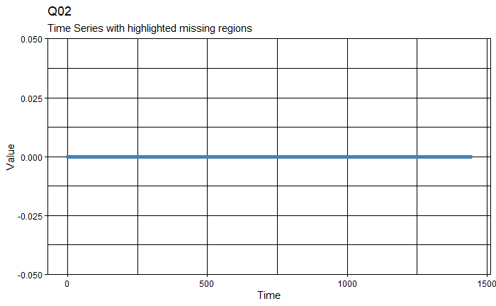

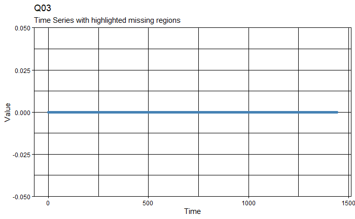

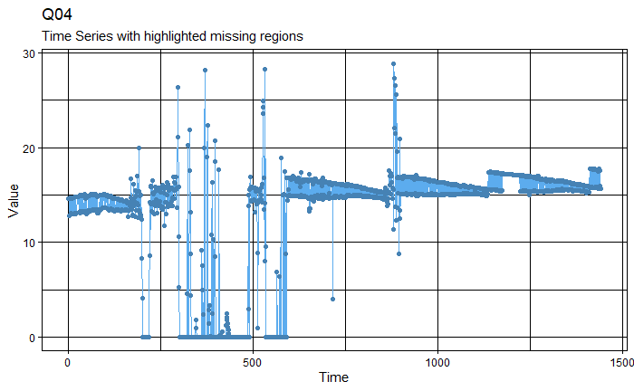

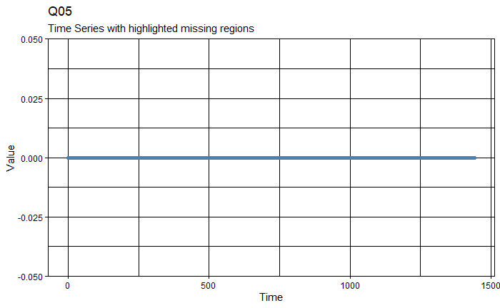

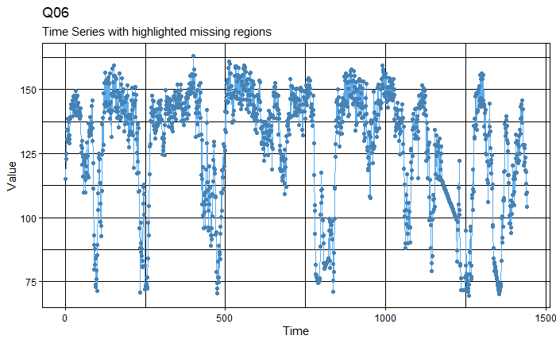

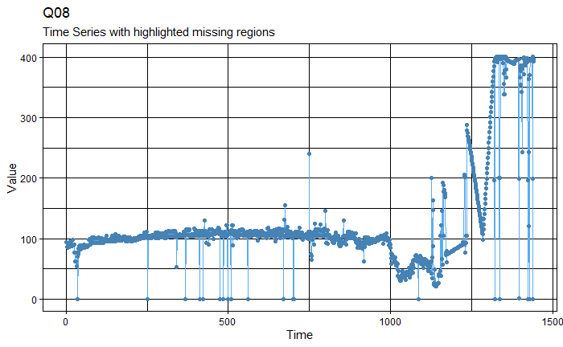

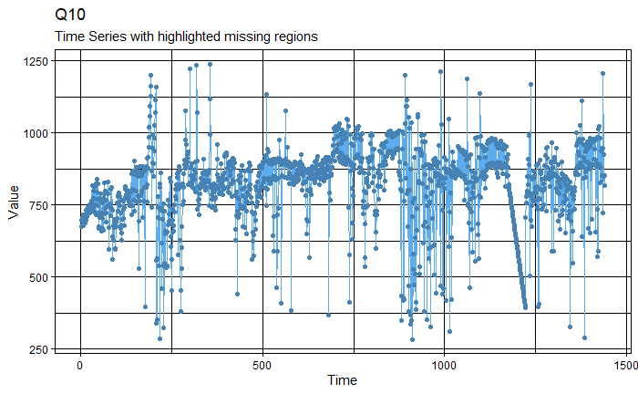

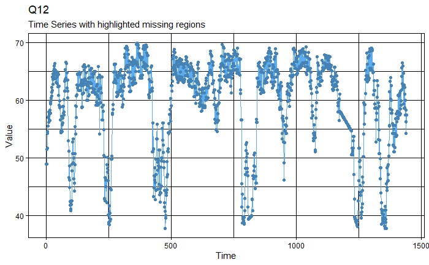

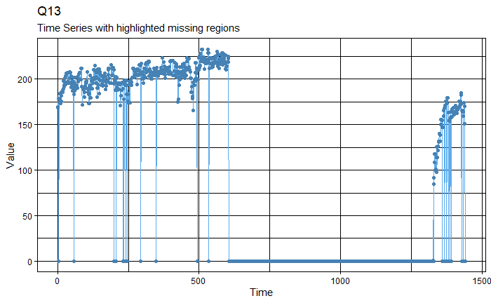

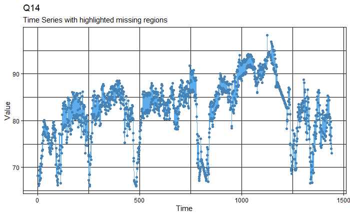

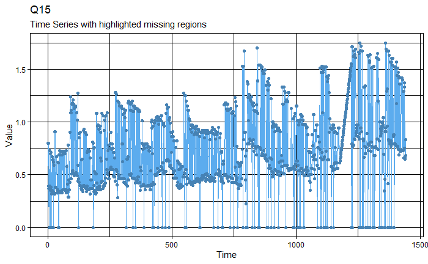

[1 more figures not shown]

```r
df %>% plot_each_q(variable)
```

We need to clean up how Q08, Q15, and Q13 seem to dip to 0 sporadically. The interpolate_0s() function can handle this. Then we can use regress_one_q_on_others() to “fix” some of these timeseries over specified time intervals. For example Q13 from around the 14th till the 30th seems to be a sensor error. We can use regress_one_q_on_others() to impute this time interval. We can do the same to “fix” Q04 around the 7th-14th and Q08 from around the 22nd till the end.

```r
df <- interpolate_0s(df, variable, "Q08")
df <- interpolate_0s(df, variable, "Q15")
df <- interpolate_0s(df, variable, "Q13")
q_to_change <- "Q13"
df <- regress_one_q_on_others(df, variable, q_to_change,
                              xs=quantifiers[!quantifiers %in% c(q_to_change,"Q10", "Q05", "Q01", "Q02", "Q03", "Q15")],
                              time_a=ymd_hms("2021-10-14 12:00:00", tz="Canada/Saskatchewan"),
                              time_b=ymd_hms("2021-10-30 12:00:00", tz="Canada/Saskatchewan"))
q_to_change <- "Q04"
df <- regress_one_q_on_others(df, variable, q_to_change,
                              xs=quantifiers[!quantifiers %in% c(q_to_change,"Q10", "Q05", "Q01", "Q02", "Q03", "Q08", "Q13", "Q15")],
                              time_a=ymd_hms("2021-10-07 12:00:00", tz="Canada/Saskatchewan"),
                              time_b=ymd_hms("2021-10-14 12:00:00", tz="Canada/Saskatchewan"))
q_to_change <- "Q08"
df <- regress_one_q_on_others(df, variable, q_to_change,
                              xs=quantifiers[!quantifiers %in% c(q_to_change,"Q10", "Q05", "Q01", "Q02", "Q03", "Q04", "Q13", "Q15")],
                              time_a=ymd_hms("2021-10-22 00:00:00", tz="Canada/Saskatchewan"),
                              time_b=end_time)
```

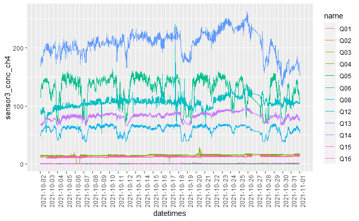

```r
df %>% plot_all_qs_dt(variable, qs_to_ignore=c("Q10"))
```

## Attempting to clean the rest…

## CO2

### Sensor 2

```r
variable <- "sensor2_conc_co2"
```

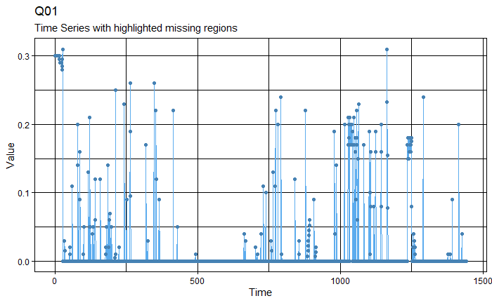

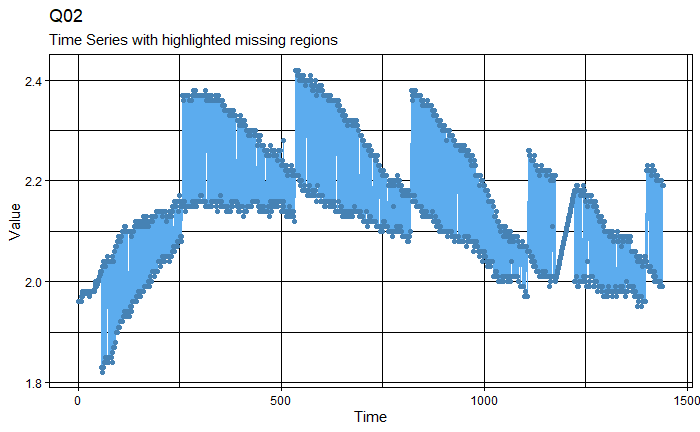

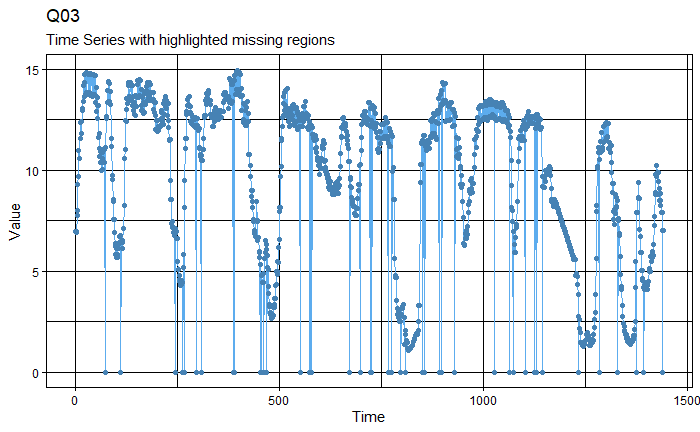

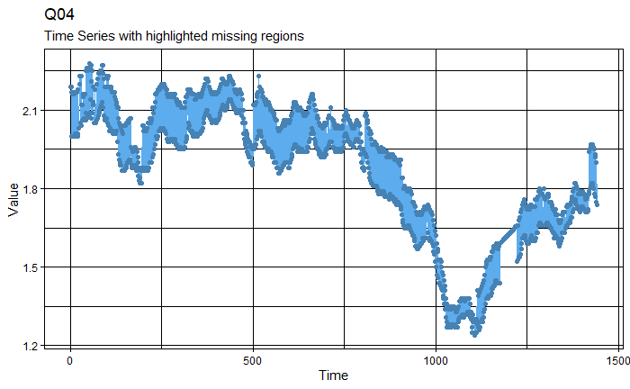

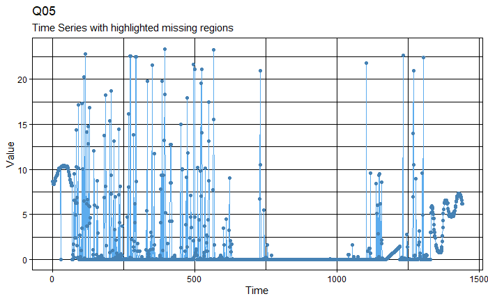

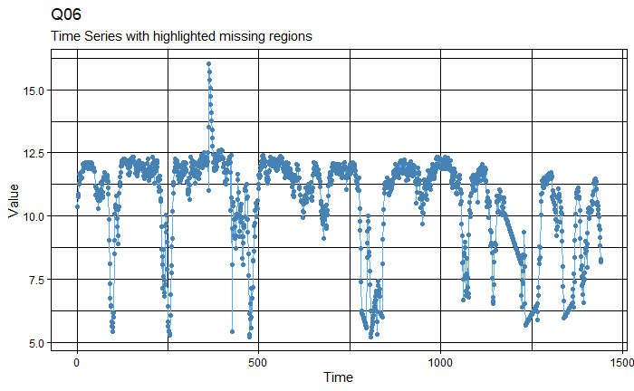

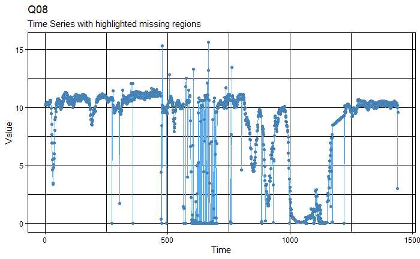

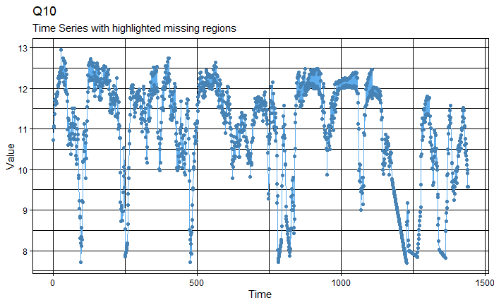

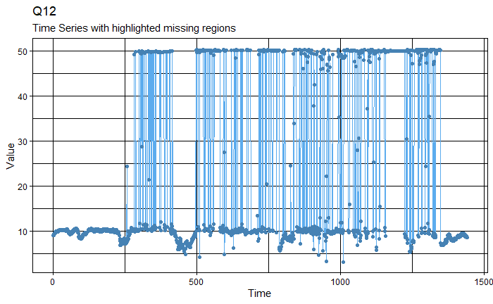

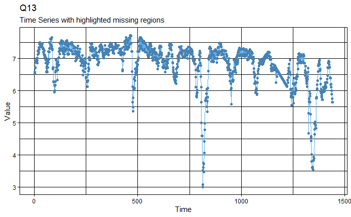

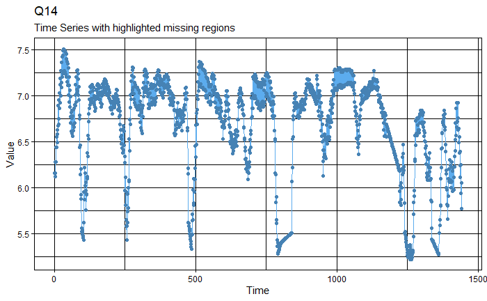

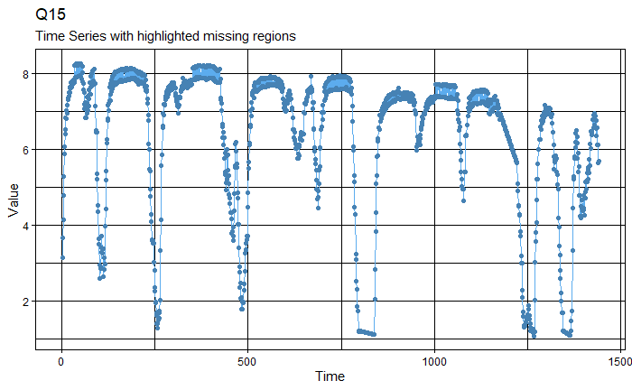

[1 more figures not shown]

```r
df %>% plot_each_q(variable)
```

```r
df %>% plot_each_q_xy(x="sensor2_oxy", y="sensor2_conc_co2")
```

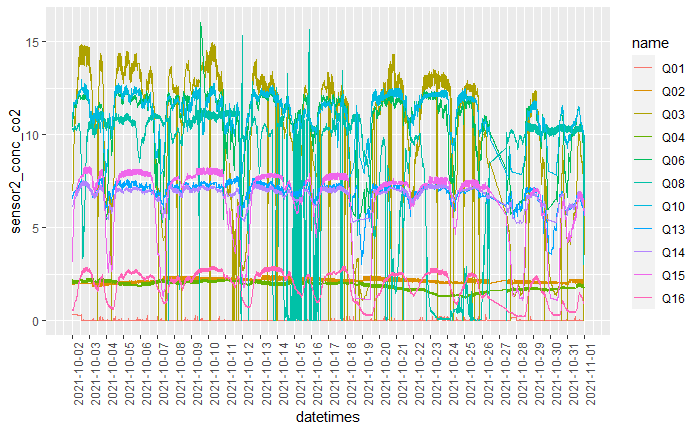

```r
df %>% plot_all_qs_dt(variable, qs_to_ignore=c("Q12", "Q05"))
```

```r
# set all Q01 to 0
df <- df %>%
  mutate("{variable}" := replace(get(variable),
                                 name=="Q01",
                                 0))
df <- interpolate_0s(df, variable, "Q03")
# for Q05, wherever oxygen is non-zero make co2 0
df <- df %>%
  mutate("{variable}" := replace(get(variable),
                                 name=="Q05" & sensor2_oxy > 0,
                                 0))
q_to_change <- "Q06"
df <- regress_one_q_on_others(df, variable, q_to_change,
                              xs=quantifiers[!quantifiers %in% c(q_to_change, "Q05", "Q01", "Q03", "Q12", "Q08")],
                              time_a=ymd_hms("2021-10-09 00:00:00", tz="Canada/Saskatchewan"),
                              time_b=ymd_hms("2021-10-10 00:00:00", tz="Canada/Saskatchewan"))
# Q08, make 0's NA's and then interpolate them
df <- interpolate_0s(df, variable, "Q08")
q_to_change <- "Q08"
df <- regress_one_q_on_others(df, variable, q_to_change,
                              xs=quantifiers[!quantifiers %in% c(q_to_change, "Q05", "Q01", "Q12")],
                              time_a=ymd_hms("2021-10-13 00:00:00", tz="Canada/Saskatchewan"),
                              time_b=ymd_hms("2021-10-22 00:00:00", tz="Canada/Saskatchewan"))
df <- regress_one_q_on_others(df, variable, q_to_change,
                              xs=quantifiers[!quantifiers %in% c(q_to_change, "Q05", "Q01", "Q12")],
                              time_a=ymd_hms("2021-10-22 12:00:00", tz="Canada/Saskatchewan"),
                              time_b=ymd_hms("2021-10-27 00:00:00", tz="Canada/Saskatchewan"))
# Q12, make > 15 NA's and then interpolate them
df <- df %>%
  mutate("{variable}" := replace(get(variable),
                                 name=="Q12" & get(variable) > 15,
                                 NA))
df <- df %>%
  mutate("{variable}" := replace(get(variable),
                                 name=="Q12",
                                 na_interpolation(df[df$name=="Q12", variable]) %>%
                                   pull(variable)))
```

```r
y <- "sensor2_conc_co2"
x <- "sensor2_oxy"
check_regression_fits(df, x, y, cols_prop_0)
```

```r
df <- impute_0s(df, x, y, cols_prop_0, manual_ignore=c("Q04", "Q05", "Q06", "Q10", "Q12"))
```

### Sensor 3

```r
variable <- "sensor3_conc_co2"
```

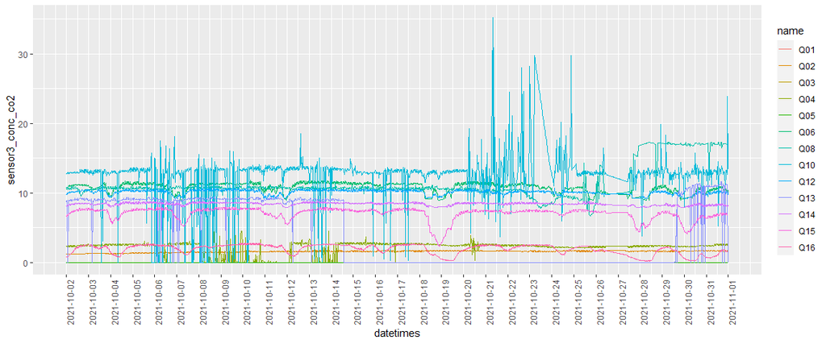

```r
df %>% plot_all_qs_dt(y=variable, qs_to_ignore=c())
```

```r
df <- df %>%
  mutate("{variable}" := replace(get(variable),
                                 name=="Q05",
                                 0))
q_to_change <- "Q13"
df <- regress_one_q_on_others(df, variable, q_to_change,
                              xs=quantifiers[!quantifiers %in% c(q_to_change, "Q05")],
                              time_a=ymd_hms("2021-10-13 12:00:00", tz="Canada/Saskatchewan"),
                              time_b=end_time)
df <- regress_one_q_on_others(df, variable, q_to_change,
                              xs=quantifiers[!quantifiers %in% c(q_to_change, "Q05")],
                              time_a=start_time,
                              time_b=ymd_hms("2021-10-06 12:00:00", tz="Canada/Saskatchewan"))
q_to_change <- "Q08"
df <- regress_one_q_on_others(df, variable, q_to_change,
                              xs=quantifiers[!quantifiers %in% c(q_to_change, "Q05")],
                              time_a=ymd_hms("2021-10-25 00:00:00", tz="Canada/Saskatchewan"),
                              time_b=end_time)
q_to_change <- "Q04"
df <- regress_one_q_on_others(df, variable, q_to_change,
                              xs=quantifiers[!quantifiers %in% c(q_to_change, "Q05")],
                              time_a=ymd_hms("2021-10-05 12:00:00", tz="Canada/Saskatchewan"),
                              time_b=ymd_hms("2021-10-14 12:00:00", tz="Canada/Saskatchewan"))
df <- regress_one_q_on_others(df, variable, q_to_change,
                              xs=quantifiers[!quantifiers %in% c(q_to_change, "Q05")],
                              time_a=ymd_hms("2021-10-15 00:00:00", tz="Canada/Saskatchewan"),
                              time_b=ymd_hms("2021-10-21 00:00:00", tz="Canada/Saskatchewan"))
q_to_change <- "Q10"
df <- regress_one_q_on_others(df, variable, q_to_change,
                              xs=quantifiers[!quantifiers %in% c(q_to_change, "Q05", "Q03", "Q13")],
                              time_a=ymd_hms("2021-10-20 00:00:00", tz="Canada/Saskatchewan"),
                              time_b=ymd_hms("2021-10-28 12:00:00", tz="Canada/Saskatchewan"))
df <- regress_one_q_on_others(df, variable, q_to_change,
                              xs=quantifiers[!quantifiers %in% c(q_to_change, "Q05", "Q03", "Q13")],
                              time_a=ymd_hms("2021-10-05 12:00:00", tz="Canada/Saskatchewan"),
                              time_b=ymd_hms("2021-10-10 12:00:00", tz="Canada/Saskatchewan"))
df <- regress_one_q_on_others(df, variable, q_to_change,
                              xs=quantifiers[!quantifiers %in% c(q_to_change, "Q05", "Q03", "Q13")],
                              time_a=ymd_hms("2021-10-12 00:00:00", tz="Canada/Saskatchewan"),
                              time_b=ymd_hms("2021-10-14 12:00:00", tz="Canada/Saskatchewan"))
df <- regress_one_q_on_others(df, variable, q_to_change,
                              xs=quantifiers[!quantifiers %in% c(q_to_change, "Q05", "Q03", "Q13")],
                              time_a=ymd_hms("2021-10-15 12:00:00", tz="Canada/Saskatchewan"),
                              time_b=ymd_hms("2021-10-18 00:00:00", tz="Canada/Saskatchewan"))
df <- regress_one_q_on_others(df, variable, q_to_change,
                              xs=quantifiers[!quantifiers %in% c(q_to_change, "Q05", "Q03", "Q13")],
                              time_a=ymd_hms("2021-10-28 12:00:00", tz="Canada/Saskatchewan"),
                              time_b=end_time)
df <- regress_one_q_on_others(df, variable, q_to_change,
                              xs=quantifiers[!quantifiers %in% c(q_to_change, "Q05", "Q03", "Q13")],
                              time_a=start_time,
                              time_b=ymd_hms("2021-10-04 12:00:00", tz="Canada/Saskatchewan"))
q_to_change <- "Q13"
df <- regress_one_q_on_others(df, variable, q_to_change,
                              xs=quantifiers[!quantifiers %in% c(q_to_change, "Q05", "Q03", "Q06", "Q10")],
                              time_a=start_time,
                              time_b=ymd_hms("2021-10-07 12:00:00", tz="Canada/Saskatchewan"))
df <- regress_one_q_on_others(df, variable, q_to_change,
                              xs=quantifiers[!quantifiers %in% c(q_to_change, "Q05", "Q03", "Q06", "Q10")],
                              time_a=ymd_hms("2021-10-06 00:00:00", tz="Canada/Saskatchewan"),
                              time_b=ymd_hms("2021-10-09 12:00:00", tz="Canada/Saskatchewan"))
df <- regress_one_q_on_others(df, variable, q_to_change,
                              xs=quantifiers[!quantifiers %in% c(q_to_change, "Q05", "Q03", "Q06", "Q10")],
                              time_a=ymd_hms("2021-10-12 00:00:00", tz="Canada/Saskatchewan"),
                              time_b=ymd_hms("2021-10-16 00:00:00", tz="Canada/Saskatchewan"))
df <- regress_one_q_on_others(df, variable, q_to_change,
                              xs=quantifiers[!quantifiers %in% c(q_to_change, "Q05", "Q03", "Q06", "Q10")],
                              time_a=ymd_hms("2021-10-22 00:00:00", tz="Canada/Saskatchewan"),
                              time_b=end_time)
df <- df %>%
  group_by(name) %>%
  mutate("{variable}" := replace(get(variable),
                                 row_number()==n(),
                                 mean(get(variable)))) %>%
  ungroup()
```

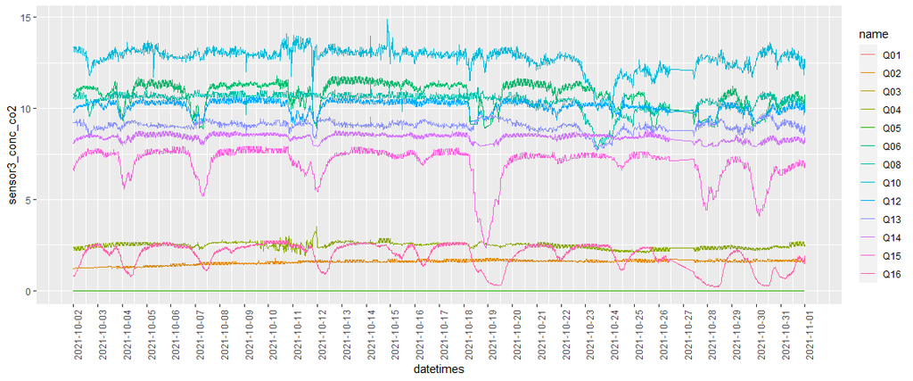

```r
df %>% plot_all_qs_dt(y=variable, qs_to_ignore=c())
```

## Oxygen

### Sensor 1

```r
variable <- "sensor1_oxy"
```

```r
df %>% plot_each_q(variable)
```

```r
df %>% plot_each_q_xy(x="sensor1_conc_co2", y="sensor1_oxy")
```

```r
df %>% plot_all_qs_dt(variable)
```

```r
y <- "sensor1_oxy"
x <- "sensor1_conc_co2"
check_regression_fits(df, x, y, cols_prop_0)
```

```r
df <- impute_0s(df, x, y, cols_prop_0, manual_ignore=c("Q02"))
```

### Sensor 2

```r
variable <- "sensor2_oxy"
```

```r
df %>% plot_each_q(variable)
```

```r
df %>% plot_each_q_xy(x="sensor2_conc_co2", y="sensor2_oxy")
```

```r
df %>% plot_all_qs_dt(variable)
```

```r
df <- df %>%
  mutate("{variable}" := replace(get(variable),
                                 name=="Q05",
                                 0))
df <- df %>%
  mutate("{variable}" := replace(get(variable),
                                 name=="Q08",
                                 0))
```

```r
y <- "sensor2_oxy"
x <- "sensor2_conc_co2"
check_regression_fits(df, x, y, cols_prop_0)
```

```r
df <- impute_0s(df, x, y, cols_prop_0, manual_ignore=c("Q02"))
```

### Sensor 3

```r
variable <- "sensor3_oxy"
```

```r
df %>% plot_each_q(variable)
```

```r
df %>% plot_each_q_xy(x="sensor3_conc_co2", y="sensor3_oxy")
```

```r
df <- df %>%
  mutate("{variable}" := replace(get(variable),
                                 name=="Q08",
                                 0))
df <- df %>%
  mutate("{variable}" := replace(get(variable),
                                 name=="Q10",
                                 0))
df <- df %>%
  mutate("{variable}" := replace(get(variable),
                                 name=="Q15" & get(variable) < 25,
                                 0))
df <- df %>%
  mutate("{variable}" := replace(get(variable),
                                 name=="Q13" & get(variable) < 0.5,
                                 0))
```

```r
check_regression_fits(df, x="sensor3_conc_co2", y="sensor3_oxy", cols_prop_0)
```

```r
df <- impute_0s(df, x, y, cols_prop_0, manual_ignore=c("Q03", "Q13"))
```

```r
df %>% plot_all_qs_dt(variable)
```

```r
df <- interpolate_0s(df, variable, "Q15")
df <- interpolate_0s(df, variable, "Q05")
```

## CH4

### Sensor 1

```r
variable <- "sensor1_conc_ch4"
```

```r
df %>% plot_each_q(variable)
```

```r
df %>% plot_each_q_xy(x="sensor1_conc_phc", y="sensor1_conc_ch4")
```

```r
df <- df %>%
  mutate("{variable}" := replace(get(variable),
                                 name=="Q05",
                                 0))
df <- df %>%
  mutate("{variable}" := replace(get(variable),
                                 name=="Q02",
                                 0))
df <- df %>%
  mutate("{variable}" := replace(get(variable),
                                 name=="Q01",
                                 0))
q_to_change <- "Q08"
df <- regress_one_q_on_others(df, variable, q_to_change,
                              xs=quantifiers[!quantifiers %in% c(q_to_change, "Q05")],
                              time_a=ymd_hms("2021-10-18 12:00:00", tz="Canada/Saskatchewan"),
                              time_b=ymd_hms("2021-10-28 12:00:00", tz="Canada/Saskatchewan"))
```

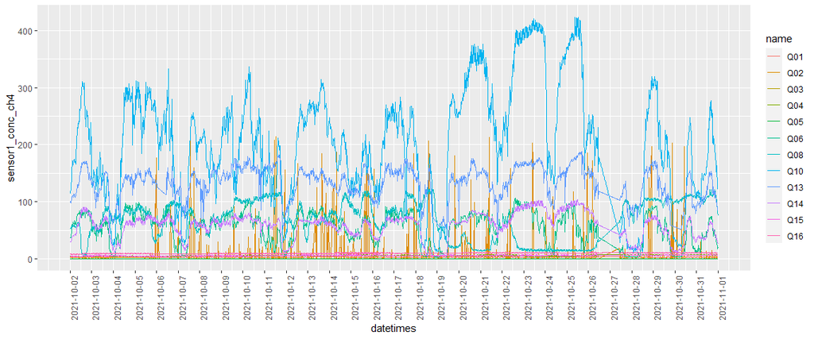

```r
df %>% plot_all_qs_dt(y=variable, qs_to_ignore=c("Q12"))
```

### Sensor 2

```r
variable <- "sensor2_conc_ch4"
```

```r
df %>% plot_each_q(variable)
```

```r
df %>% plot_each_q_xy(x="sensor2_conc_phc", y="sensor2_conc_ch4")
```

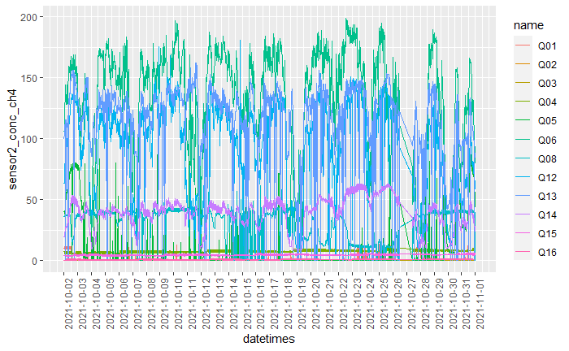

```r
df %>% plot_all_qs_dt("sensor2_conc_ch4", qs_to_ignore=c("Q10"))
```

```r
df <- df %>%
  mutate("{variable}" := replace(get(variable),
                                 name=="Q01",
                                 0))
df <- df %>%
  mutate("{variable}" := replace(get(variable),
                                 name=="Q05",
                                 0))
df <- df %>%
  mutate("{variable}" := replace(get(variable),
                                 (name=="Q08" & get(variable) > 45) | (name=="Q08" & get(variable) < 9),
                                 NA))
df <- df %>% mutate("{variable}" := replace(get(variable),
                                             name=="Q08",
                                             na_interpolation(df[df$name=="Q08", variable] %>% pull(get(variable)))))
df <- interpolate_0s(df, variable, "Q13")
q_to_change <- "Q08"
df <- regress_one_q_on_others(df, variable, q_to_change,
                              xs=quantifiers[!quantifiers %in% c(q_to_change, "Q12")],
                              time_a=ymd_hms("2021-10-18 12:00:00", tz="Canada/Saskatchewan"),
                              time_b=end_time)
```

### Sensor 3

```r
variable <- "sensor3_conc_ch4"
```

```r
df %>% plot_each_q(variable)
```

```r
df %>% plot_each_q_xy(x="sensor3_conc_phc", y="sensor3_conc_ch4")
```

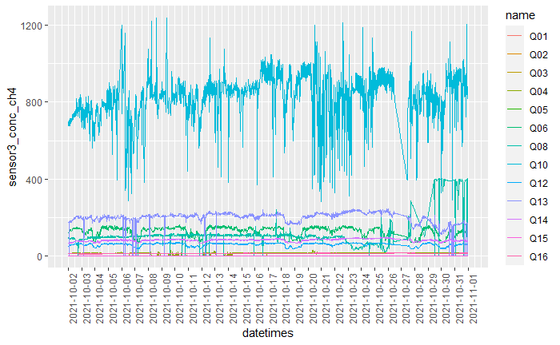

```r
df %>% plot_all_qs_dt(variable, qs_to_ignore=c())
```

## PHC

Ignored for now as we aren’t currently using it for any of the reports

## Pid

### Sensor 1

```r
variable <- "sensor1_pid"
```

```r
df %>% plot_each_q(variable)
```

```r
df %>% plot_each_q_xy(x="datetimes", y=variable)
```

```r
df %>% plot_all_qs_dt(variable)
```

```r
time_a <- ymd_hms("2021-10-12 12:00:00", tz="Canada/Saskatchewan")
time_b <- ymd_hms("2021-10-15 00:00:00", tz="Canada/Saskatchewan")
df <- df %>%
  mutate("{variable}" := replace(get(variable),
                                 name=="Q01" & datetimes > time_a & datetimes < time_b,
                                 0))
df <- interpolate_0s(df, variable, "Q01")
```

### Sensor 2

```r
variable <- "sensor2_pid"
```

```r
df %>% plot_each_q(variable)
```

```r
df %>% plot_all_qs_dt(variable)
```

```r
df <- df %>%
  mutate("{variable}" := replace(get(variable),
                                 name=="Q05",
                                 2000))
df <- interpolate_0s(df, variable, "Q13")
q_to_change <- "Q04"
df <- regress_one_q_on_others(df, variable, q_to_change,
                              xs=quantifiers[!quantifiers %in% c(q_to_change)],
                              time_a=ymd_hms("2021-10-29 00:00:00", tz="Canada/Saskatchewan"),
                              time_b=end_time)
q_to_change <- "Q08"
df <- regress_one_q_on_others(df, variable, q_to_change,
                              xs=quantifiers[!quantifiers %in% c(q_to_change)],
                              time_a=ymd_hms("2021-10-18 00:00:00", tz="Canada/Saskatchewan"),
                              time_b=end_time)
q_to_change <- "Q15"
df <- regress_one_q_on_others(df, variable, q_to_change,
                              xs=quantifiers[!quantifiers %in% c(q_to_change, "Q05")],
                              time_a=ymd_hms("2021-10-15 00:00:00", tz="Canada/Saskatchewan"),
                              time_b=end_time)
```

### Sensor 3

```r
variable <- "sensor3_pid"
```

```r
df %>% plot_each_q(variable)
```

```r
df <- interpolate_0s(df, variable, "Q03")
df <- interpolate_0s(df, variable, "Q05")
df <- interpolate_0s(df, variable, "Q08")
df <- interpolate_0s(df, variable, "Q16")
df <- df %>%
  mutate("{variable}" := replace(get(variable),
                                 name=="Q06",
                                 0))
q_to_change <- "Q10"
df <- regress_one_q_on_others(df, variable, q_to_change,
                              xs=quantifiers[!quantifiers %in% c(q_to_change, "Q13", "Q06")],
                              time_a=start_time,
                              time_b=ymd_hms("2021-10-20 15:00:00", tz="Canada/Saskatchewan"))
q_to_change <- "Q08"
df <- regress_one_q_on_others(df, variable, q_to_change,
                              xs=quantifiers[!quantifiers %in% c(q_to_change)],
                              time_a=ymd_hms("2021-10-18 00:00:00", tz="Canada/Saskatchewan"),
                              time_b=end_time)
q_to_change <- "Q13"
df <- regress_one_q_on_others(df, variable, q_to_change,
                              xs=quantifiers[!quantifiers %in% c(q_to_change)],
                              time_a=ymd_hms("2021-10-11 12:00:00", tz="Canada/Saskatchewan"),
                              time_b=ymd_hms("2021-10-30 00:00:00", tz="Canada/Saskatchewan"))
```

```r
df2 %>% plot_all_qs_dt(y=variable, qs_to_ignore=c())
```

## Pid Correction

0.53(pid - mean(background))

Currently we clip negative values to 0.00001 and then rescale to the desired right sensor rather than clipping to the right sensor.

```r
background <- "Q01"

background_mean_pid_1 <- df %>%
  filter(name == background) %>%
  pull(sensor1_pid) %>%
  mean()
background_mean_pid_2 <- df %>%
  filter(name == background) %>%
  pull(sensor2_pid) %>%
  mean()
background_mean_pid_3 <- df %>%
  filter(name == background) %>%
  pull(sensor3_pid) %>%
  mean()
df <- df %>%
  mutate(sensor1_pid_corr = 0.53 * (sensor1_pid - background_mean_pid_1),
         sensor2_pid_corr = 0.53 * (sensor2_pid - background_mean_pid_2),
         sensor3_pid_corr = 0.53 * (sensor3_pid - background_mean_pid_3))

# clip < 0 to 0.00001
df <- df %>%
  mutate(sensor1_pid_corr = ifelse(sensor1_pid_corr < 0, 0.00001, sensor1_pid_corr),
         sensor2_pid_corr = ifelse(sensor2_pid_corr < 0, 0.00001, sensor2_pid_corr),
         sensor3_pid_corr = ifelse(sensor3_pid_corr < 0, 0.00001, sensor3_pid_corr))

# right sensor: sensor1 = 20, sensor2 = 200, sensor3 = 2000
# rescale
df <- df %>%
  mutate(sensor1_pid_corr = rescale(sensor1_pid_corr, to=c(0.00001, 20)),
         sensor2_pid_corr = rescale(sensor2_pid_corr, to=c(0.00001, 200)),
         sensor3_pid_corr = rescale(sensor3_pid_corr, to=c(0.00001, 2000)))
```

# Save the cleaned data

```r
write.csv(df, "../data/site_A_cleaned.csv", row.names=FALSE)
```